# Tarea 6: Sistemas de Recomendación (parte 2)

Alejandra Lelo de Larrea Ibarra

09/03/2019

# Preparación

Consideramos el conjunto chico de calificaciones de películas de [MovieLens](https://grouplens.org/datasets/movielens/). Son unas 100 mil evaluaciones de 610 usuarios sobre 9 mil películas.

## Datos

```r
# Cargamos librería
library(tidyverse)
library(gridExtra)
# Leemos los datos
movies <- read_csv("../datos/ml-latest-small/movies.csv")
ratings <- read_csv("../datos/ml-latest-small/ratings.csv")
# Vemos la base de datos de los ratings
ratings
```

```
## # A tibble: 100,836 x 4
##    userId movieId rating timestamp
##     <dbl>   <dbl>  <dbl>     <dbl>
##  1      1       1      4 964982703
##  2      1       3      4 964981247
##  3      1       6      4 964982224
##  4      1      47      5 964983815
##  5      1      50      5 964982931
##  6      1      70      3 964982400
##  7      1     101      5 964980868
##  8      1     110      4 964982176
##  9      1     151      5 964984041
## 10      1     157      5 964984100
## # ... with 100,826 more rows
```

Tenemos datos del id de usuario, el id de la pelicula, la calificación que le dieron y la marca del tiempo.

```r
# No de calificaciones
nrow(ratings)
```

```
## [1] 100836
```

Se tiene un total de 100836 calificaciones.

```r
# No de evaluaciones por usuario
resumen <- ratings %>% # datos ratings
  group_by(userId) %>% # agrupa por usuario
  summarise(num_ratings = length(rating)) # calcula no de eval.

# Distribución del no. de calificaciones por usuario
quantile(resumen$num_ratings)
```

```
##     0%    25%    50%    75%   100%
##   20.0   35.0   70.5  168.0 2698.0
```

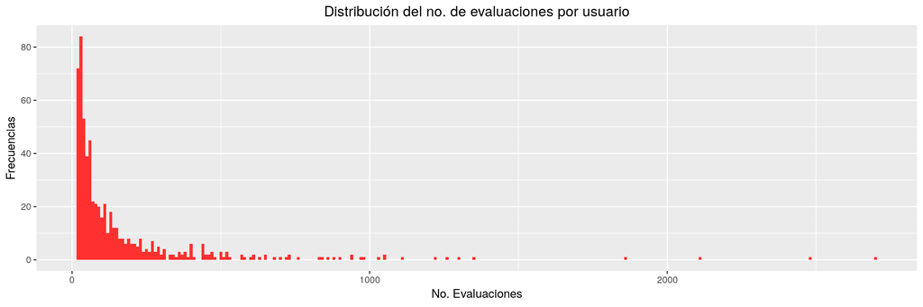

```r
ggplot(resumen,aes(x=num_ratings))+
  geom_histogram(binwidth = 10,fill='firebrick1')+
  ggtitle('Distribución del no. de evaluaciones por usuario')+
  xlab('No. Evaluaciones')+
  ylab('Frecuencias')+
  theme(plot.title = element_text(hjust=0.5))
```

Vemos que el 50% de los usuarios tienen entre 20 y 70 calificaciones. Hay muy pocos usuarios con un número altísimo de evaluaciones. En promedio, un usuario tiene 165.304918 evaluaciones.

```r
# Vemos la base de datos de las películas
movies
```

```
## # A tibble: 9,742 x 3
##    movieId title                        genres
##      <dbl> <chr>                        <chr>
##  1       1 Toy Story (1995)             Adventure|Animation|Children|Comed…
##  2       2 Jumanji (1995)               Adventure|Children|Fantasy
##  3       3 Grumpier Old Men (1995)      Comedy|Romance
##  4       4 Waiting to Exhale (1995)     Comedy|Drama|Romance
##  5       5 Father of the Bride Part II… Comedy
##  6       6 Heat (1995)                  Action|Crime|Thriller
##  7       7 Sabrina (1995)               Comedy|Romance
##  8       8 Tom and Huck (1995)          Adventure|Children
##  9       9 Sudden Death (1995)          Action
## 10      10 GoldenEye (1995)             Action|Adventure|Thriller
## # ... with 9,732 more rows
```

Se tiene el id de la película, el título y los géneros a los que pertenece.

```r
# No de películas
nrow(movies)
```

```
## [1] 9742
```

En total, se tienene 9742 películas en la base de datos.

## Datos de Validación y Entrenamiento

```r
length(unique(ratings$userId))
```

```
## [1] 610
```

Se tiene un total de 610 usuarios. Seleccionamos 300 usuarios para la muestra de validación

```r
# Fija la semilla
set.seed(5512)

# Selecciona aleatoriamente 300 usuarios de validación de los 610 disponibles
user_id_valid <- ratings$userId %>% unique %>% sample(size = 300)
```

Y seleccionamos el 20% de las últimas evaluaciones de estos usuarios:

```r
# Selecciona 20% de evaluaciones.
validacion <- ratings %>% # datos ratings
  filter(userId %in% user_id_valid) %>% # extrae usuarios en validación
  group_by(userId) %>% # agrupa por usuario
  mutate(rank = rank(timestamp, ties.method = "random") / length(timestamp)) %>% # ordena observaciones
  filter(rank >= 0.8) # se queda con el último 20% de la muestra

# no de calificaciones en validación
nrow(validacion)
```

```
## [1] 9803
```

El conjunto de validación tiene 300 usuarios y 9,803 calificaciiones.

```r
# Extrae los datos de entrenamiento
entrena <- ratings %>% anti_join(validacion)
# No de obs de entrenamiento
nrow(entrena)
```

```
## [1] 91033
```

### Pregunta 1

¿Cuáles son las películas mejor evaluadas? Reporta la media y el número de evaluaciones. Recuerda filtrar por películas que han sido poco vistas. Describe la distribución de número de evaluaciones por usuario (usa cuantiles o un histograma, por ejemplo). ¿Cuántas evaluaciones hizo el usuario con menos evaluaciones?

Para los datos de entrenamiento, extraemos la media y el no. de evaluaciones por película. Filtramos aquellas películas que tienen más de 100 evaluaciones. Las películas mejor evaluadas son:

```r
p1<-entrena %>% # datos entrenamiento
  group_by(movieId) %>% # agrupa por película
  summarise(calif_prom=mean(rating),
            num_eval=n())

p1_a<-p1%>% # calcula media y no. eval
  arrange(desc(calif_prom,num_eval)) %>% #ordena observaciones
  filter(num_eval>100) %>% # Filtra por número de calificaciones
  left_join(select(movies,movieId,title),by='movieId') %>% # Agrega título de pelicula
  select(movieId,title,calif_prom,num_eval)

DT::datatable(p1_a)
```

|  | movieId | title | calif_prom | num_eval |
| --- | --- | --- | --- | --- |
| 1 | 318 | Shawshank Redemption, The (1994) | 4.42033898305085 | 295 |
| 2 | 858 | Godfather, The (1972) | 4.29459459459459 | 185 |
| 3 | 2959 | Fight Club (1999) | 4.25870646766169 | 201 |
| 4 | 1213 | Goodfellas (1990) | 4.25 | 114 |
| 5 | 58559 | Dark Knight, The (2008) | 4.24460431654676 | 139 |
| 6 | 1221 | Godfather: Part II, The (1974) | 4.23360655737705 | 122 |
| 7 | 1197 | Princess Bride, The (1987) | 4.23333333333333 | 135 |
| 8 | 1208 | Apocalypse Now (1979) | 4.22772277227723 | 101 |
| 9 | 50 | Usual Suspects, The (1995) | 4.22164948453608 | 194 |
| 10 | 1196 | Star Wars: Episode V - The Empire Strikes Back (1980) | 4.22058823529412 | 204 |

[output cut: 99 more lines]

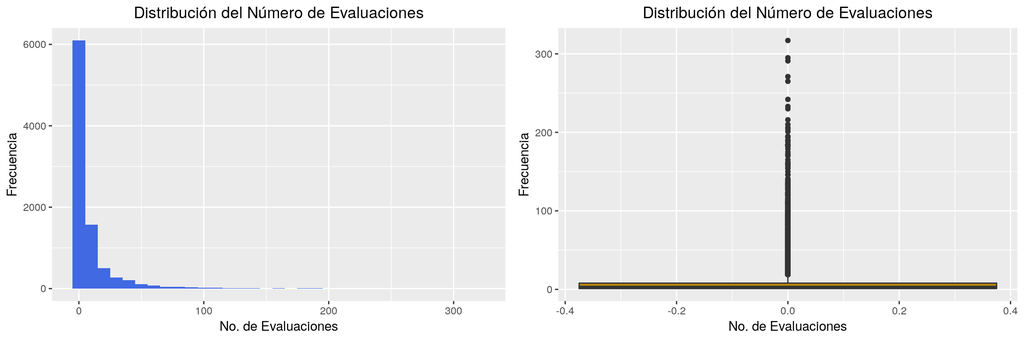

```r
q1<-ggplot(p1,aes(x=num_eval)) +
  geom_histogram(binwidth=10,fill='royalblue') +
  ggtitle('Distribución del Número de Evaluaciones')+
  xlab('No. de Evaluaciones')+
  ylab('Frecuencia')+
  theme(plot.title = element_text(hjust=0.5))

q2<-ggplot(p1,aes(y=num_eval)) +
  geom_boxplot(fill='darkgoldenrod') +
  ggtitle('Distribución del Número de Evaluaciones')+
  xlab('No. de Evaluaciones')+
  ylab('Frecuencia')+
  theme(plot.title = element_text(hjust=0.5))

grid.arrange(q1,q2,nrow=1)
```

```r
quantile(p1$num_eval)
```

```
##   0%  25%  50%  75% 100%
##    1    1    3    8  317
```

```r
summary(p1$num_eval)
```

```
##    Min. 1st Qu.  Median    Mean 3rd Qu.    Max.
##    1.00    1.00    3.00   10.01    8.00  317.00
```

De las gráficas y tablas anteriores, para el número de evaluaciones podemos notar que:

- La distribución está sesgada a la derecha. Es decir, son pocas las películas que tienen un gran número de evaluaciones.
- El número promedio de evaluaciones por película es de 10.
- El 50% de las películas en la muestra tienen entre 1 y 3 evaluaciones.
- Sólo el 25% de la muestra tienen más de 8 evaluaciones.
- La película con más evaluaciones es Forrest Gump (1994).

### Pregunta 2

Explica el proceso de selección de la muestra de validación para este ejemplo (ojo: utiliza el timestamp de la calificación).

Para seleccionar la muestra de validacion, elegimos aleatoriamente prácticamente el 50% de los usuarios en la muestra (300 de los 610 disponibles). Para cada uno de estos usuarios, se ordena las películas evaluadas por el timestamp (ie. momento en que vieron las películas) y seleccionamos el ultimo 20% de películas vistas por los usuarios. Esto ayuda a incoroporar el hecho de que queremos hacer predicciones para películas vistas en un futuro.

# Evaluación de modelo de referencia

## Cálculo de promedios

```r
# Calif promedio y no. de evaluaciones por película
pelis_medias <- entrena %>% # datos entrenamiento
  group_by(movieId) %>% # agrupa por película
  summarise(media_peli = mean(rating), num_eval = length(rating)) # calcula calif. promedio y no de eval.

# Califiación promedio por usuario
usuarios_medias <- entrena %>% # datos entrenamiento
  group_by(userId) %>% # agrupa por usuario
  summarise(media_usuario = mean(rating)) # calcula calif.promedio

# Promedio general
media_gral <- mean(entrena$rating)
```

## Cálculo de Predicciones

```r
# Modelo de referencia para los datos de entrenamiento
entrena_ref <- entrena %>% # datos de entrenamiento
  ungroup %>% # desagrupa el id de usuario
  left_join(pelis_medias) %>% # Agrega media de cada película
  left_join(usuarios_medias) %>% # Agrega la media de cada usuario
  mutate(pred = media_peli + (media_usuario - media_gral)) %>% # pred. modelo base.
  mutate(pred = ifelse(is.na(pred), media_gral, pred)) %>% # asigna media general a los na's
  mutate(rating_c = rating - pred) # calcula la diferencia de la calif con la predicción base
# Obtiene las predicciones con el modelo de referencia para el conjunto de validación
valida_ref <- validacion %>% # datos validación
  ungroup %>% # desagurpa por id de usuario
  left_join(pelis_medias) %>% # agrega media de peliculas
  left_join(usuarios_medias) %>% # agrega media de usuarios
  mutate(pred = media_peli + (media_usuario - media_gral)) %>% # pred. modelo base.
  mutate(pred = ifelse(is.na(pred), media_gral, pred)) # asigna media general a los na's
```

### Pregunta 3

Calcula la raíz del error cuadrático medio del modelo de referencia (entrenamiento y validación).

```r
# Función para calcular la raíz del error cuadrático medio.
recm <- function(calif, pred){
  sqrt(mean((calif - pred)^2))
}

error_entrena<-recm(entrena_ref$rating,entrena_ref$pred)

error_valida<-recm(valida_ref$rating,valida_ref$pred)
```

El error de entrenamiento es de 0.818799 y el error de validación es de 0.9622512. El error de validación es un poco más grande que el de entrenamiento (diferencia de 0.1434522).

# Mínimos cuadrados alternados

## Conexión a spark

Ahora probamos mínimos cuadrados alternados con 2 factores latentes

```r
# Cargamos la librería de spark
library(sparklyr)
# Nos conectamos a spark
sc <- spark_connect(master = "local")

# Establecemos el checkpoint
spark_set_checkpoint_dir(sc, './checkpoint')
```

## Datos con ajuste por medias

En este ejemplo, ajustamos por media de películas y usuarios antes de correr el modelo:

```r
# Cargamos los datos de enternamiento con el modelo de referencia a spark
entrena_tbl <- copy_to(sc, entrena_ref, overwrite = T)

# Cargamos los datos de validación con el modelo de referencia a spark
valida_tbl <- copy_to(sc, valida_ref, overwrite = T)
```

## Modelo de factores latentes

Corremos el modelo de dos factores latentes con los siguientes parámetros:

- rating_col = rating_c (desviaciones)
- user_col = userId
- item_col = movieId
- rank = 2

```r
# rellena valores (usa rango 2 al principio)
modelo <- ml_als(entrena_tbl,
                 rating_col = 'rating_c',
                 user_col = 'userId',
                 item_col = 'movieId',
                 rank = 2,
                 reg_param = 0.1,
                 checkpoint_interval = 5,
                 max_iter = 50)
```

## Predicciones

Calcula las predicciones y coléctalas al ambiente de R:

```r
# Calcula las predicciones para el conjunto de validación
preds_valida<- sdf_predict(valida_tbl, modelo) %>% # predicciones para validación
  collect() %>% # las extrae a R.
  mutate(final_pred = pred + prediction)%>% # Suma el modelo base a las predicciones de desviaciones.
  mutate(final_pred = ifelse(is.na(final_pred), media_gral, final_pred)) # Asigna media general para aquellas que no tienen prediccion

# Calcula las predicciones para el conjunto de validación
preds_entrena <- sdf_predict(entrena_tbl, modelo) %>% # predicciones para entrenamiento
  collect() %>% # las extrae a R.
  mutate(final_pred = pred + prediction) # Suma el modelo base a laspredicciones de desviaciónes.
```

### Pregunta 4

Explica por qué el cálculo de *final_pred*. Calcula el error de entrenamiento y validación para este modelo.

Se necesita calcular el valor de **final_pred** porque el modelo se ajusta a las deviaciones de las predicciones del modelo base respecto de las calificaciones observadas. Para regresar a la escala original es necesario sumar el modelo base a las predicciones de las desviaciones.

Para los errores tenemos:

```r
# Error de entrenamiento bajo MCA
error_entrena_MCA<-recm(preds_entrena$rating,preds_entrena$final_pred)

# Error de validación bajo MCA
error_valida_MCA<-recm(preds_valida$rating,preds_valida$final_pred)
```

El error de entrenamiento bajo mínimos cuadrados alternados es de 0.721806 y el error de validación es de 0.9493279. El error de validación sigue siendo un poco más grande que el de entrenamiento (diferencia de 0.2275219). Respecto al modelo base, el error de validación disminuyó pasando de 0.9622512 a 0.9493279.

### Pregunta 5

Según los resultados que obtuviste en la pregunta anterior, intenta incrementar o decrementar la regularización. Reporta error de entrenamiento y validación.

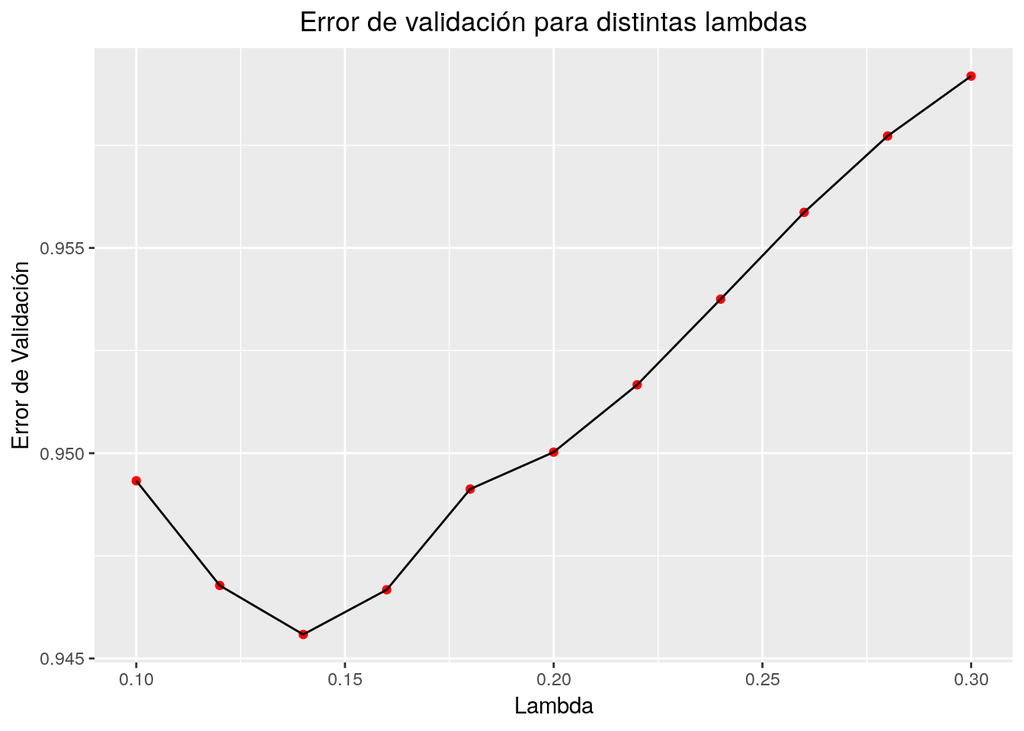

```r
calcula_regparam<-function(factores){

  fun<-function(lambda){

    # Corremos el modelo para la lambda especificada
    mod <- ml_als(entrena_tbl,
                  rating_col = 'rating_c',
                  user_col = 'userId',
                  item_col = 'movieId',
                  rank = factores,
                  reg_param = lambda,
                  checkpoint_interval = 5,
                  max_iter = 50)

    # Calcula las predicciones para el conjunto de validación
    preds_valida<- sdf_predict(valida_tbl, mod) %>% # predicciones para validación
      collect() %>% # las extrae a R.
      mutate(final_pred = pred + prediction)%>% # Suma el modelo base a las predicciones de desviaciones.
      mutate(final_pred = ifelse(is.na(final_pred), media_gral, final_pred)) # Asigna media general para aquellas que no tienen prediccion


    # Calcula el error de validación bajo MCA
    error_valida<-recm(preds_valida$rating,preds_valida$final_pred)
    error_valida

  }

  fun
}

calcula_regparam_2factores<-calcula_regparam(factores=2)

# Posibles valores de lambda
lambdas<-seq(from=0.1,to=0.3,by=0.02)

# Error de validación para cada lambda
errores_valida_lambdas<-lapply(lambdas,calcula_regparam_2factores)%>%unlist

# Crea data frame
data_plot<-data_frame(lambdas,errores_valida_lambdas)

# Grafica los datos
ggplot(data_plot,aes(x=lambdas,y=errores_valida_lambdas))+
  geom_point(color='red')+
  geom_line()+
  ggtitle('Error de validación para distintas lambdas')+
  xlab('Lambda')+
  ylab('Error de Validación')+
  theme(plot.title=element_text(hjust=0.5))
```

```r
lambda_star=data_plot$lambdas[which.min(data_plot$errores_valida_lambdas)]
```

```r
# Se corre el modelo con la lambda que genera el menor error de validación
modelo2 <- ml_als(entrena_tbl,
                  rating_col = 'rating_c',
                  user_col = 'userId',
                  item_col = 'movieId',
                  rank = 2,
                  reg_param = lambda_star,
                  checkpoint_interval = 5,
                  max_iter = 50)


# Calcula las predicciones para el conjunto de validación
preds_valida2<- sdf_predict(valida_tbl, modelo2) %>% # predicciones para validación
  collect() %>% # las extrae a R.
  mutate(final_pred = pred + prediction)%>% # Suma el modelo base a las predicciones de desviaciones.
  mutate(final_pred = ifelse(is.na(final_pred), media_gral, final_pred)) # Asigna media general para aquellas que no tienen prediccion


# Calcula las predicciones para el conjunto de validación
preds_entrena2 <- sdf_predict(entrena_tbl, modelo2) %>% # predicciones para entrenamiento
  collect() %>% # las extrae a R.
  mutate(final_pred = pred + prediction) # Suma el modelo base a laspredicciones de desviaciónes.


# Error de entrenamiento bajo MCA
error_entrena_MCA2<-recm(preds_entrena2$rating,preds_entrena2$final_pred)

# Error de validación bajo MCA
error_valida_MCA2<-recm(preds_valida2$rating,preds_valida2$final_pred)
```

Al estimar el modelo con una regularización de 0.14 se obtiene un error de entrenamiento bajo mínimos cuadrados alternados es de 0.7361139 y el error de validación es de 0.9455837. El error de validación sigue siendo un poco más grande que el de entrenamiento (diferencia de 0.2094699). Respecto al modelo base, el error de validación disminuyó pasando de 0.9622512 a 0.9455837. Respecto al modelo con el parametro de regularización anterior se tiene que el error de validación disminuyó pasando de 0.9493279 a 0.9455837.

### Pregunta 6 (opcional)

Cambia el número de factores y afina la regularización para mejorar los resultados del inciso anterior.

```r
t<-Sys.time()
params<-list(factores=3:5,
             lambda=seq(0.02,1,by=0.02))%>%
  expand.grid

params$error_valida<-apply(params,1,function(x){
  mod<-calcula_regparam(x[1])
  mod(x[2])
})

t<-Sys.time()-t
t
```

```
## Time difference of 49.41322 mins
```

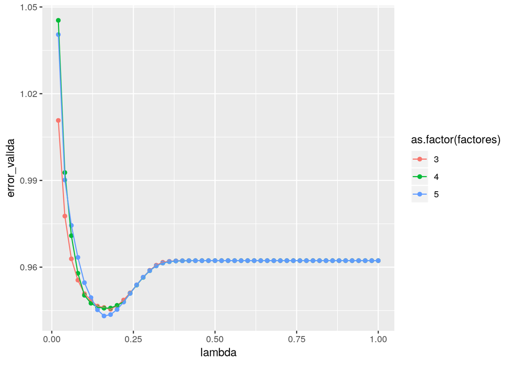

```r
ggplot(params,aes(x=lambda,y=error_valida,group=as.factor(factores),color=as.factor(factores)))+
  geom_point()+
  geom_line()
```

```r
params_star<-params[which.min(params$error_valida),]
params_star
```

```
##    factores lambda error_valida
## 24        5   0.16    0.9431066
```

```r
# Se corre el modelo con la lambda que genera el menor error de validación
modelo3 <- ml_als(entrena_tbl,
                  rating_col = 'rating_c',
                  user_col = 'userId',
                  item_col = 'movieId',
                  rank = as.numeric(params_star[1]),
                  reg_param = as.numeric(params_star[2]),
                  checkpoint_interval = 5,
                  max_iter = 50)


# Calcula las predicciones para el conjunto de validación
preds_valida3<- sdf_predict(valida_tbl, modelo3) %>% # predicciones para validación
  collect() %>% # las extrae a R.
  mutate(final_pred = pred + prediction)%>% # Suma el modelo base a las predicciones de desviaciones.
  mutate(final_pred = ifelse(is.na(final_pred), media_gral, final_pred)) # Asigna media general para aquellas que no tienen prediccion


# Calcula las predicciones para el conjunto de validación
preds_entrena3 <- sdf_predict(entrena_tbl, modelo3) %>% # predicciones para entrenamiento
  collect() %>% # las extrae a R.
  mutate(final_pred = pred + prediction) # Suma el modelo base a laspredicciones de desviaciónes.


# Error de entrenamiento bajo MCA
error_entrena_MCA3<-recm(preds_entrena3$rating,preds_entrena3$final_pred)
error_entrena_MCA3
```

```
## [1] 0.7015253
```

```r
# Error de validación bajo MCA
error_valida_MCA3<-recm(preds_valida3$rating,preds_valida3$final_pred)
error_valida_MCA3
```

```
## [1] 0.9431066
```

Al aumentar el número de factores a 5 con un parametro de regularización de 0.16 se obtiene un error de entrenamiento bajo mínimos cuadrados alternados es de 0.7015253 y el error de validación es de 0.9431066. El error de validación sigue siendo un poco más grande que el de entrenamiento (diferencia de 0.2415813).

- Respecto al modelo base, el error de validación disminuyó pasando de 0.9622512 a 0.9431066.
- Respecto al modelo con dos factores y parámetro de regularización de 0.1 se tiene que el error de validación disminuyó pasando de 0.9493279 a 0.9431066.
- Respecto al modelo con dos factores y parámetro de regularización óptimo se tiene que el error de validación disminuyó pasando de 0.9455837 a 0.9431066.